# FIN_654_WK3_R

##### Fisher Transformation

*First, the Fisher transformation is a smoothing routine that helps us tabilize the volitility of a variate. It does this by pulling some of the shockiness (i.e., outliers and aberrant noise) out of the original time series. In a phrase,* TL;DR: **it helps us see the forest (or the wood) for the trees.** NOTE: Post lecture – good to know but do not use. Better resources out there.

```r
require(xts)
require(qrmdata)
require(quantreg)
require(quantmod)
require(matrixStats)
tickers <- c("ELE.MC", "IBE.MC", "REP.MC")
getSymbols(tickers)
```

[output not shown]

```
## [1] "ELE.MC" "IBE.MC" "REP.MC"
```

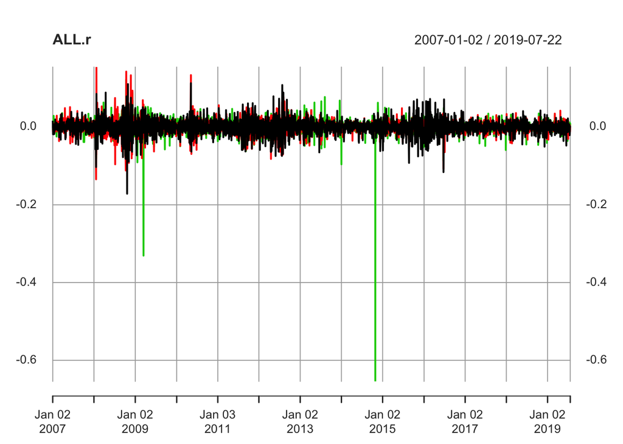

```r
REP.r <- na.omit(diff(log(REP.MC[,4]))[-1])
IBE.r <- na.omit(diff(log(IBE.MC[,4]))[-1])
ELE.r <- na.omit(diff(log(ELE.MC[,4]))[-1])
ALL.r <- na.omit(merge(REP = REP.r, IBE=IBE.r, ELE= ELE.r, all=FALSE))
plot(ALL.r)
```

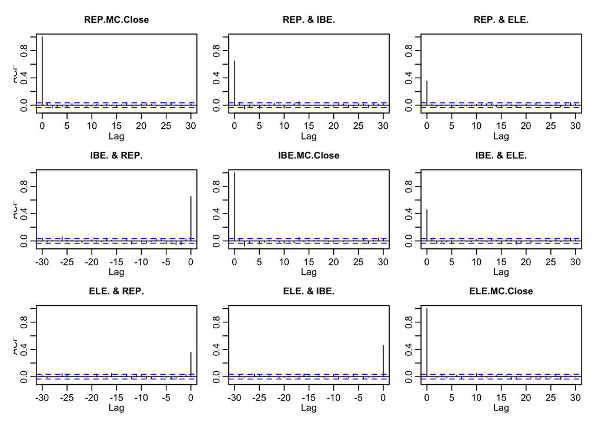

```r
par(mfrow = c(2, 1))
acf(ALL.r)
```

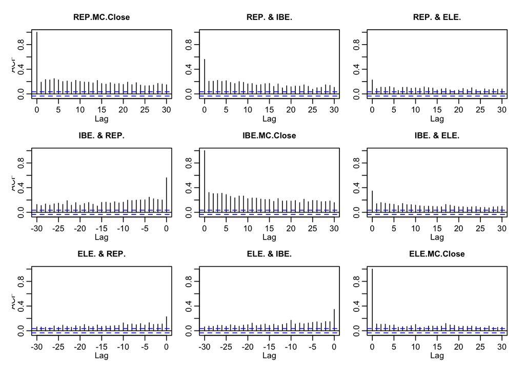

```r
par(mfrow = c(2, 1))
acf(abs(ALL.r))
```

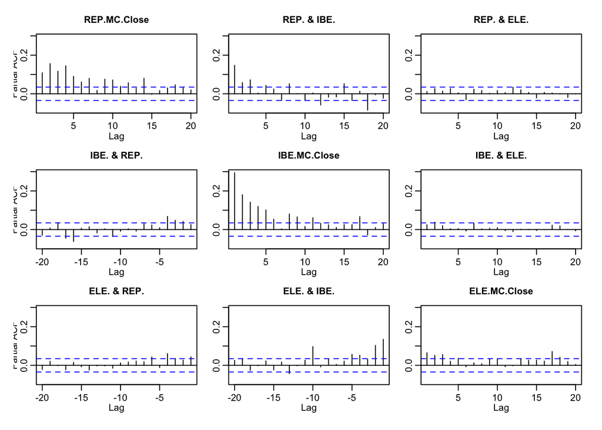

```r
par(mfrow = c(2, 1))
pacf(abs(ALL.r), lag.max=20)
```

## 3.5 Exercise: Time is on our Side

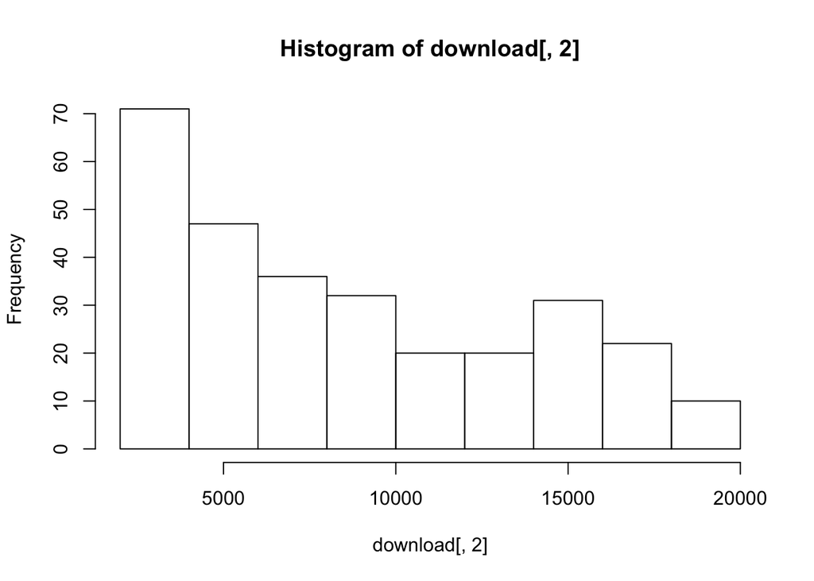

```r
name <- "GNP"
download <- read.csv("data/GNPC96.csv")
hist(download[,2])
```

```r
summary(download[,2])
```

```
##    Min. 1st Qu.  Median    Mean 3rd Qu.    Max.
##    2037    4101    7058    8647   13279   19156
```

```r
GNP <- ts(download[1:85, 2], start = c(1995, 1), freq = 4)
GNP.rate <- 100 * diff(log(GNP))  # In percentage terms
str(GNP)
```

```
##  Time-Series [1:85] from 1995 to 2016: 2046 2041 2037 2069 2101 ...
```

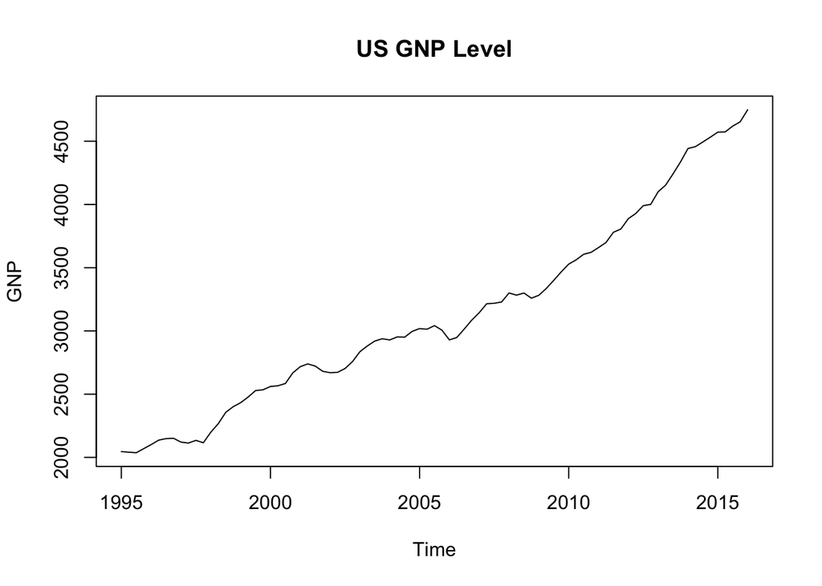

```r
plot(GNP, type = "l", main = "US GNP Level")
```

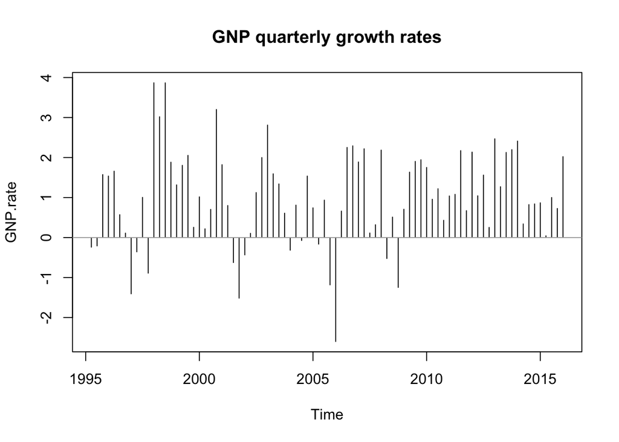

```r
plot(GNP.rate, type = "h", main = "GNP quarterly growth rates")
abline(h = 0, col = "darkgray")
```

### Forecasting GNP

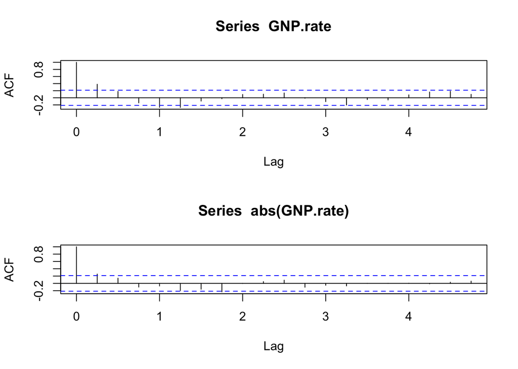

```r
par(mfrow = c(2, 1))
acf(GNP.rate)
acf(abs(GNP.rate))
```

Fitrate using ARIMA (Autoregressive Integrated Moving Average)

```r
(fit.rate <- arima(GNP.rate, order = c(2, 1, 1)))
```

```
##
## Call:
## arima(x = GNP.rate, order = c(2, 1, 1))
##
## Coefficients:
##          ar1     ar2      ma1
##       0.3829  0.0542  -1.0000
## s.e.  0.1106  0.1109   0.0381
##
## sigma^2 estimated as 1.202:  log likelihood = -127.16,  aic = 262.31
```

```r
(fit.rate.2 <- arima(GNP.rate, order = c(2, 0, 0)))
```

```
##
## Call:
## arima(x = GNP.rate, order = c(2, 0, 0))
##
## Coefficients:
##          ar1     ar2  intercept
##       0.3700  0.0415     0.9992
## s.e.  0.1092  0.1095     0.2002
##
## sigma^2 estimated as 1.188:  log likelihood = -126.49,  aic = 260.98
```

## 3.6 Exercise: Give it the Boot

Efficient Market Hypothesis

## 3.7 The Wrap

New ways to do Exploratory Data Analysis – Auto correlation – Cross correlation – Average regression & quantile regression ===

END